# Praktikum Responsi Komstat Pertemuan 14

Alwan Rahmana

2022-06-08

## Pendahuluan

Import data kabupaten/kota

```r
data_kabkota<-read.csv("C:/Users/HP/OneDrive - Universitas Diponegoro/Documents/Kulon STIS IV/Komstat/Praktik/data_kabkota.csv")
```

## Korelasi

Korelasi adalah istilah statistik yang digunakan untuk menyatakan derajat hubungan linear anta dua variabel. Besarnya nilai korelasi adalah di antara -1 sampai dengan 1. Sebenarnya, nilai korelasi hanya berkisar 0 sampai 1, tetapi perbedaan tanda (+)/(-) menunjukkan arah hubungan dari kedua variabel. Hubungan yang searah direpresentasikan dengan tanda (+), sedangkan hubungan yang berlawanan ditandai dengan (-).

Adapun, jenis korelasi yang digunakan merupakan korelasi Moment Pearson. Jenis korelasi ini digunakan untuk mengetahui hubungan linear antar variabel dengan skala pengukuran interval atau rasio.

syntax: Cor(x,y)

```r
View(data_kabkota)
df <- data.frame(select(data_kabkota,RLS_2020,PKP_2020,UHH_2020,HLS_2020))
cor(df$RLS_2020,df$HLS_2020)
```

```
## [1] 0.778586
```

## Regresi Linear Sederhana

Persamaan regresi sederhana adalah salah satu metode statistik untuk mengetahui sejauh mana hubungan sebab akibat antara variabel dependent (terikat) dengan variabel independent (bebas) melalui persamaan regresi linear sederhana. syntax: reg_model <-lm(y~x) summary(reg_model)

```r
reg_model <- lm(HLS_2020 ~ RLS_2020, data = df)
summary(reg_model)
```

```
##
## Call:
## lm(formula = HLS_2020 ~ RLS_2020, data = df)
##
## Residuals:
##     Min      1Q  Median      3Q     Max
## -4.7697 -0.4816 -0.0035  0.5323  2.4955
##
## Coefficients:
##             Estimate Std. Error t value Pr(>|t|)
## (Intercept)   7.6627     0.1921   39.88   <2e-16 ***
## RLS_2020      0.6345     0.0226   28.07   <2e-16 ***
## ---
## Signif. codes:  0 '***' 0.001 '**' 0.01 '*' 0.05 '.' 0.1 ' ' 1
##
## Residual standard error: 0.8359 on 512 degrees of freedom
## Multiple R-squared:  0.6062, Adjusted R-squared:  0.6054
## F-statistic: 788.1 on 1 and 512 DF,  p-value: < 2.2e-16
```

Berdasarkan output di atas, didapatkan hasil bahwa:

1. Model regresinya adalah *y* = *7.6627* + *0.6345x*
2. variabel x (RLS_2020) secara signifikan berpengaruh terhadap model, terlihat dari *p-value* yang kecil dan kurang dari taraf uji 5%
3. Koefisien Determinasi menunjukkan bahwa variabel Harapan Lama Sekolah (HLS) dapat dijelaskan oleh variabel Rata Lama Sekolah (RLS) sebesar 60,62%. Dan sekitar 39,38% dijelaskan oleh variabel lain di luar model

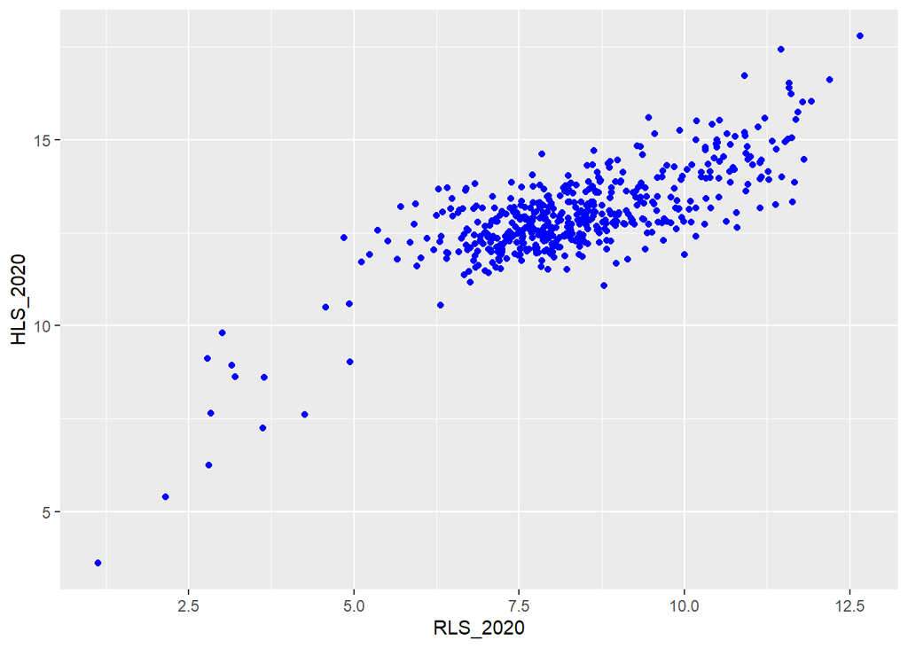

```r
#Create graph
ggplot(df,aes(x=RLS_2020,y=HLS_2020))+  geom_point(color='blue')
```